# Introduction to the `panelr` package

## Fitting within-between models

The workhorse function for within-between models is `wbm()`, which is built on top of `lme4`’s `lmerMod()` and `glmerMod()`. It is not so hard to understand how to treat your data to estimate within-between models, but the programming can be a challenge to those who aren’t skilled with R (or whatever else they might use) and is error-prone in any case.

The main thing to know in order to use `wbm()` is how the model formula works, because it’s a little different from your typical regression model. It is split into up to 3 parts, each for a different kind of variable. Each part is separated by a `|`. The pattern is like this:

```
dependent ~ time_varying | time_invariant | cross_lev_interactions + (random_slopes | id)
```

So you start with your dependent variable on the left-hand side like normal and then what comes next are variables that vary over time. You will only get within-entity estimates for these variables. Next are time-invariant variables; the between-entity terms for the time-varying variables are added automatically so no need to try to include them here. Finally, in the third part you can specify cross-level interactions (i.e., within-entity by between-entity/time-invariant) as well as additional random effects terms using the `lme4`-style syntax. By default, `(1 | id)` (or whatever the ID variable is) is added internally for a random intercept so you do not need to include it yourself.

Let’s walk through an example with the `wages` data we looked at briefly earlier. We’ll predict the logarithm of wages (`lwage`) using weeks worked (`wks`), union membership (`union`), marital status (`ms`), blue (vs. white) collar job status (`occ`), black race (`blk`), and female sex (`fem`).

```r
model <- wbm(lwage ~ wks + union + ms + occ | blk + fem, data = wages)
summary(model)
```

```
MODEL INFO:
Entities: 595
Time periods: 1-7
Dependent variable: lwage
Model type: Linear mixed effects
Specification: within-between

MODEL FIT:
AIC = 2036.78, BIC = 2119.13
Pseudo-R² (fixed effects) = 0.27
Pseudo-R² (total) = 0.69
Entity ICC = 0.57

WITHIN EFFECTS:
------------------------------------------
               Est.   S.E.   t val.      p
----------- ------- ------ -------- ------
wks            0.00   0.00     1.06   0.29
union          0.06   0.03     2.53   0.01
ms            -0.08   0.03    -2.57   0.01
occ           -0.08   0.02    -3.32   0.00
------------------------------------------

BETWEEN EFFECTS:
-------------------------------------------------
                      Est.   S.E.   t val.      p
------------------ ------- ------ -------- ------
(Intercept)           6.30   0.20    30.85   0.00
imean(wks)            0.01   0.00     2.25   0.02
imean(union)          0.15   0.03     4.67   0.00
imean(ms)             0.17   0.05     3.07   0.00
imean(occ)           -0.41   0.03   -13.31   0.00
blk                  -0.15   0.05    -2.81   0.00
fem                  -0.32   0.06    -4.96   0.00
-------------------------------------------------

p values calculated using df = 4153

RANDOM EFFECTS:
------------------------------------
  Group      Parameter    Std. Dev.
---------- ------------- -----------
    id      (Intercept)    0.2992
 Residual                  0.2589
------------------------------------
```

As you can see, the output distinguishes within- and between-entity effects. When you see `imean()` around a variable, that is the between-entity effect represented as the individual mean.

Here, we see there seems to be a wage penalty for switching from white collar to blue collar work (`occ`) and although married people earn more (`imean(ms)`), just becoming married (`ms`) coincides with a drop in earnings. We also see a boost in earnings from joining a union (`union`).

Maybe we think the timing of the marriage effect is off and the true effect occurs the time period after a person becomes married. We can ask for the lagged effect using `lag()`.

```r
model <- wbm(lwage ~ wks + union + lag(ms) + occ | blk + fem, data = wages)
summary(model)
```

```
MODEL INFO:
Entities: 595
Time periods: 2-7
Dependent variable: lwage
Model type: Linear mixed effects
Specification: within-between

MODEL FIT:
AIC = 1247.06, BIC = 1327.41
Pseudo-R² (fixed effects) = 0.28
Pseudo-R² (total) = 0.74
Entity ICC = 0.64

WITHIN EFFECTS:
--------------------------------------------
                 Est.   S.E.   t val.      p
------------- ------- ------ -------- ------
wks             -0.00   0.00    -1.43   0.15
union            0.05   0.03     1.82   0.07
lag(ms)         -0.04   0.03    -1.19   0.23
occ             -0.06   0.02    -2.56   0.01
--------------------------------------------

BETWEEN EFFECTS:
---------------------------------------------------
                        Est.   S.E.   t val.      p
-------------------- ------- ------ -------- ------
(Intercept)             6.36   0.21    30.51   0.00
imean(wks)              0.01   0.00     2.25   0.02
imean(union)            0.15   0.03     4.48   0.00
imean(lag(ms))          0.15   0.06     2.80   0.01
imean(occ)             -0.41   0.03   -13.16   0.00
blk                    -0.15   0.05    -2.92   0.00
fem                    -0.33   0.06    -5.17   0.00
---------------------------------------------------

p values calculated using df = 3558

RANDOM EFFECTS:
------------------------------------
  Group      Parameter    Std. Dev.
---------- ------------- -----------
    id      (Intercept)    0.3068
 Residual                  0.2325
------------------------------------
```

Well that doesn’t change the direction of the estimate, but it also moved it sufficiently close to 0 that we can’t say much about it one way or another.

Keep in mind that you do not have to stick to linear models. Using the `family` argument (just like `glm()`), you can estimate logit (`family = binomial`), probit (`family = binomal(link = "probit")`), poisson (`family = poisson`), or other model families and links as needed.

### Growth curves

Now maybe we want to include an effect of time since wages tend to go up for everyone, on average, over time. We can just include the time variable in the formula or set `use.wave` to `TRUE`.

```r
model <- wbm(lwage ~ wks + union + ms + occ | blk + fem, data = wages, use.wave = TRUE)
summary(model)
```

```
MODEL INFO:
Entities: 595
Time periods: 1-7
Dependent variable: lwage
Model type: Linear mixed effects
Specification: within-between

MODEL FIT:
AIC = -1688.87, BIC = -1600.19
Pseudo-R² (fixed effects) = 0.44
Pseudo-R² (total) = 0.89
Entity ICC = 0.8

WITHIN EFFECTS:
------------------------------------------
               Est.   S.E.   t val.      p
----------- ------- ------ -------- ------
wks            0.00   0.00     1.91   0.06
union          0.03   0.02     2.29   0.02
ms            -0.03   0.02    -1.71   0.09
occ           -0.03   0.01    -1.81   0.07
------------------------------------------

BETWEEN EFFECTS:
-------------------------------------------------
                      Est.   S.E.   t val.      p
------------------ ------- ------ -------- ------
(Intercept)           5.91   0.20    28.95   0.00
imean(wks)            0.01   0.00     2.25   0.02
imean(union)          0.15   0.03     4.67   0.00
imean(ms)             0.17   0.05     3.07   0.00
imean(occ)           -0.41   0.03   -13.31   0.00
blk                  -0.15   0.05    -2.81   0.00
fem                  -0.32   0.06    -4.96   0.00
t                     0.10   0.00    81.29   0.00
-------------------------------------------------

p values calculated using df = 4152

RANDOM EFFECTS:
------------------------------------
  Group      Parameter    Std. Dev.
---------- ------------- -----------
    id      (Intercept)    0.3094
 Residual                  0.1533
------------------------------------
```

Including `t` wipes out some of those previously observed effects. Believe it or not, we just fit a growth curve model!

Now, we might think people have different trajectories. We can include that as a random slope, which will go in the third part of the formula.

```r
model <- wbm(lwage ~ wks + union + ms + occ | blk + fem | (t | id), use.wave = TRUE, data = wages)
summary(model)
```

```
MODEL INFO:
Entities: 595
Time periods: 1-7
Dependent variable: lwage
Model type: Linear mixed effects
Specification: within-between

MODEL FIT:
AIC = -2064.42, BIC = -1963.07
Pseudo-R² (fixed effects) = 0.43
Pseudo-R² (total) = 0.92
Entity ICC = 0.84

WITHIN EFFECTS:
------------------------------------------
               Est.   S.E.   t val.      p
----------- ------- ------ -------- ------
wks            0.00   0.00     1.47   0.14
union          0.02   0.01     1.61   0.11
ms            -0.04   0.02    -1.97   0.05
occ           -0.02   0.01    -1.42   0.16
------------------------------------------

BETWEEN EFFECTS:
-------------------------------------------------
                      Est.   S.E.   t val.      p
------------------ ------- ------ -------- ------
(Intercept)           5.93   0.20    29.69   0.00
imean(wks)            0.01   0.00     2.12   0.03
imean(union)          0.16   0.03     4.90   0.00
imean(ms)             0.17   0.05     3.25   0.00
imean(occ)           -0.39   0.03   -13.16   0.00
blk                  -0.13   0.05    -2.49   0.01
fem                  -0.31   0.06    -4.90   0.00
t                     0.10   0.00    54.67   0.00
-------------------------------------------------

p values calculated using df = 4152

RANDOM EFFECTS:
------------------------------------
  Group      Parameter    Std. Dev.
---------- ------------- -----------
    id      (Intercept)    0.3057
    id           t         0.03499
 Residual                  0.1334
------------------------------------
```

And now we have a latent growth curve model. The general effect on the other coefficients is more uncertainty and attenuated estimates. It’s worth keeping in mind that it is sometimes wrong to use a growth curve model like this if you think the variables in your model *cause* the time trend; if you think wages are going up because more people are moving into white collar work, then including the growth curve will make it harder for you to see the true effect of `occ`.

### Contextual, within, and random effects specifications

By default, `wbm()` does as the name suggests. But if you’d rather have the contextual model described earlier, in which the means are not subtracted from the time varying variables, that’s an option too.

```r
model <- wbm(lwage ~ wks + union + ms + occ | blk + fem, data = wages, model = "contextual")
summary(model)
```

```
MODEL INFO:
Entities: 595
Time periods: 1-7
Dependent variable: lwage
Model type: Linear mixed effects
Specification: contextual

MODEL FIT:
AIC = 2036.78, BIC = 2119.13
Pseudo-R² (fixed effects) = 0.27
Pseudo-R² (total) = 0.69
Entity ICC = 0.57

WITHIN EFFECTS:
------------------------------------------
               Est.   S.E.   t val.      p
----------- ------- ------ -------- ------
wks            0.00   0.00     1.06   0.29
union          0.06   0.03     2.53   0.01
ms            -0.08   0.03    -2.57   0.01
occ           -0.08   0.02    -3.32   0.00
------------------------------------------

CONTEXTUAL EFFECTS:
-------------------------------------------------
                      Est.   S.E.   t val.      p
------------------ ------- ------ -------- ------
(Intercept)           6.30   0.20    30.85   0.00
imean(wks)            0.01   0.00     1.93   0.05
imean(union)          0.09   0.04     2.15   0.03
imean(ms)             0.25   0.06     3.95   0.00
imean(occ)           -0.33   0.04    -8.55   0.00
blk                  -0.15   0.05    -2.81   0.00
fem                  -0.32   0.06    -4.96   0.00
-------------------------------------------------

p values calculated using df = 4153

RANDOM EFFECTS:
------------------------------------
  Group      Parameter    Std. Dev.
---------- ------------- -----------
    id      (Intercept)    0.2992
 Residual                  0.2589
------------------------------------
```

Now the individual means have a new interpretation as the difference in effect compared to the within-entity estimates.

If you don’t want to use any of the time-invariant variables, you can also just ask for the “within” estimator:

```r
model <- wbm(lwage ~ wks + union + ms + occ, data = wages, model = "within")
summary(model)
```

```
MODEL INFO:
Entities: 595
Time periods: 1-7
Dependent variable: lwage
Model type: Linear mixed effects
Specification: within

MODEL FIT:
AIC = 2266.01, BIC = 2310.35
Pseudo-R² (fixed effects) = 0
Pseudo-R² (total) = 0.69
Entity ICC = 0.69

------------------------------------------------
                     Est.   S.E.   t val.      p
----------------- ------- ------ -------- ------
(Intercept)          6.68   0.02   413.08   0.00
wks                  0.00   0.00     1.06   0.29
union                0.06   0.03     2.53   0.01
ms                  -0.08   0.03    -2.57   0.01
occ                 -0.08   0.02    -3.32   0.00
------------------------------------------------

p values calculated using df = 4159

RANDOM EFFECTS:
------------------------------------
  Group      Parameter    Std. Dev.
---------- ------------- -----------
    id      (Intercept)    0.3819
 Residual                  0.2589
------------------------------------
```

This can help declutter your output when you really just don’t care about the between-subjects effects.

## Predictions and interaction plots

Predicting panel histories and plotting hypothetical combinations of predictors are different operations. `predict(model, newdata = histories)` recomputes person means from the supplied histories, so those data must include the entity identifier and enough history for the desired within-person interpretation. Include the wave variable for time effects, detrending, lags, and leads. The outcome is not needed unless it also serves as a predictor. Predictions retain the input row order.

For interaction plots, panelr holds person means and interaction-product means fixed at their observation-weighted averages in the estimation sample. With an updated version of interactions that supports `plot.scale`, numeric within-person predictors are displayed as **deviations from each person’s observed mean**, in the variable’s original units. Zero means at the person’s mean, not a raw value of zero. Time-invariant moderators retain their original units or categories. For example:

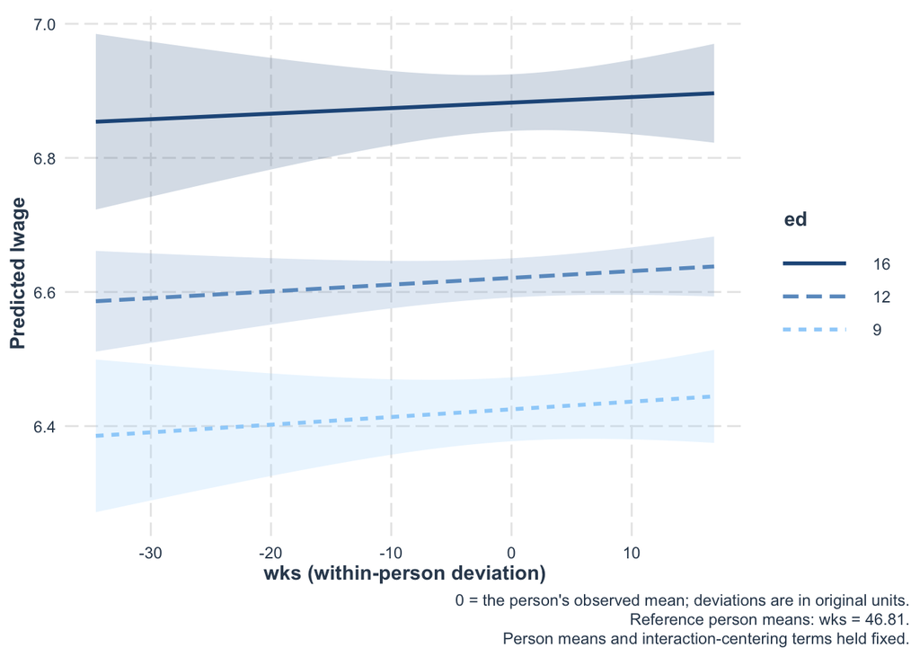

```r
interaction_model <- wbm(lwage ~ wks | ed | wks * ed, data = wages,
                         pR2 = FALSE, pvals = FALSE)
interactions::interact_plot(interaction_model, pred = wks, modx = ed,
                           modx.values = c(9, 12, 16), interval = TRUE)
```

Here, `wks = -5` means five fewer weeks worked than the person’s mean, while `ed = 12` still means twelve years of education. The outcome axis shows predicted `lwage`, not a deviation in wages. In a model interacting two varying predictors:

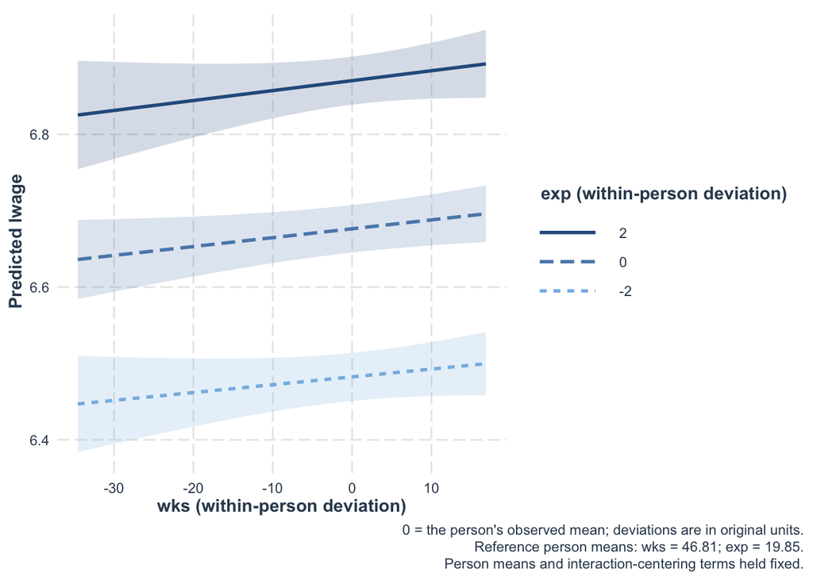

```r
within_interaction <- wbm(lwage ~ wks * exp, data = wages,
                          pR2 = FALSE, pvals = FALSE)
interactions::interact_plot(within_interaction, pred = wks, modx = exp,
                           interval = TRUE)
```

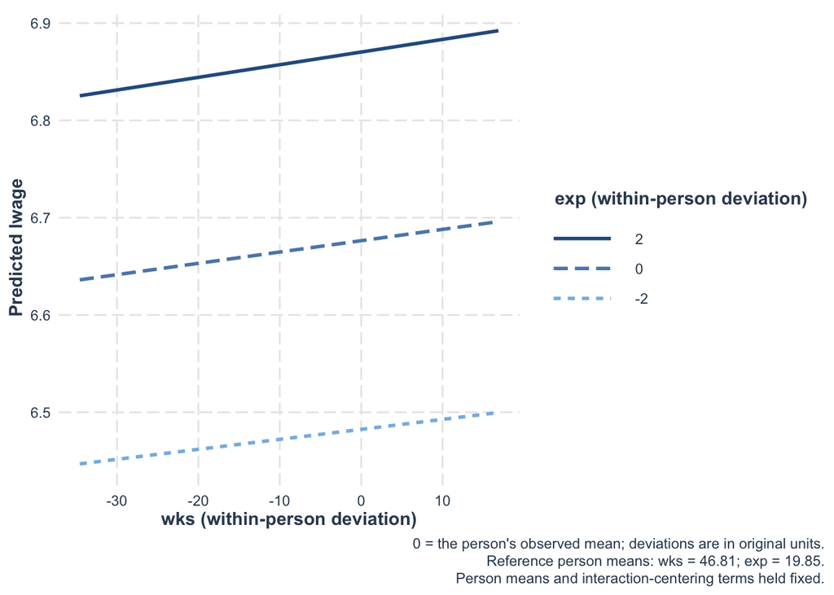

```r
# Explicit values are deviations too: -2, 0, +2 years from the person's mean.
interactions::interact_plot(within_interaction, pred = wks, modx = exp,
                           modx.values = c(-2, 0, 2))
```

Default moderator values are zero and plus/minus one pooled within-person SD, about two years for experience here, rather than SDs of raw experience across people. The numeric axis range uses observed within-person deviations. These display units are unchanged when the fitted model uses `scale = TRUE`.

Use `plot.scale = "original"` to display raw predictor levels. For example, `modx.values = c(18, 20, 22), plot.scale = "original"` requests experience levels of 18, 20, and 22 years, relative to the reference person mean shown in the caption. It does not request deviations of those magnitudes. Predictions outside observed within-person ranges generate warnings; staying within each marginal range does not guarantee joint support.

The plot does not recalculate person means from the displayed grid. The lines therefore represent conditional predictions, not population-average effects or forecasts for particular people. Reference means can be overridden through `at`, for example `at = list("imean(wks)" = 45)`. These mean overrides are always in original units; other numeric `at` values use the display scale. With within-scale displays, changing the reference mean does not change what a displayed deviation of zero means. For within-by-within interactions, the product-centering reference, such as `imean(x:z)`, is also held fixed unless explicitly overridden. Time-invariant moderators multiply the centered within-person term, respecting the fact that they factor out of the centering operation. Confidence bands describe fixed-effect uncertainty conditional on these reference values, not individual prediction intervals.

Custom axis and legend labels override the generated labels. Supplied `data` must contain fitting-data observations with their panel identifiers; subsets retain the fitted person means. Use `at` to set hypothetical profiles. Direct calls to `jtools::make_predictions()` and older interactions versions without the new `plot.scale` argument still use original-scale predictor inputs.

`predict(..., raw = TRUE)` is a separate interface for already-prepared model-scale data. It never recalculates interaction columns or person means. This argument is unrelated to the fitting option `interaction.style = "raw"`. For plots from explicitly prepared rows, use `jtools::make_predictions(model, pred = "x", new_data = rows, raw = TRUE)`.

Automatic grids currently support scalar numeric/factor terms and two- or three-way interactions. Scalar transformations such as `log(x)` require `plot.scale = "original"`, because deviations in `log(x)` and `x` are not the same quantity. For detrending, lags/leads, or basis expansions, use complete panel histories or prepared model-scale rows. Partial residuals and custom plotting covariance estimates are not yet supported.

### Simple slopes

Updated interactions versions provide S3 methods for `sim_slopes()` and `johnson_neyman()` that use the same transformed design rows as the plots. They do not recenter the original data and refit the model: person-mean centering would undo a constant shift of a time-varying moderator in a double-demeaned interaction.

```r
interactions::sim_slopes(within_interaction, pred = wks, modx = exp,
                         modx.values = c(-2, 0, 2), confint = TRUE, digits = 4)
```

```
Fixed-effect slopes on the response scale (identity link). Numeric
within-person predictors/moderators use deviations in original units. t
approximation with 4157 degrees of freedom (not
Satterthwaite/Kenward-Roger). 0 = the person's observed mean; deviations
are in original units. Reference person means: wks = 46.81; exp = 19.85.
Person means and interaction-centering terms held fixed.

JOHNSON-NEYMAN ANALYSIS

Fixed-effect slopes: response scale (identity link). t(4157) approximation;
not Satterthwaite/Kenward-Roger. 0 = the person's observed mean; deviations
are in original units. Reference person means: wks = 46.81; exp = 19.85.
Person means and interaction-centering terms held fixed.

The slope does not exclude zero at the selected confidence level anywhere
on the moderator scale.

Observed moderator range: [-3.0000, 3.0000]. Regions beyond this range
extrapolate.

SIMPLE SLOPES ANALYSIS

Slope of wks when exp = -2.0000:

    Est.     S.E.      2.5%    97.5%   t val.        p
-------- -------- --------- -------- -------- --------
  0.0010   0.0008   -0.0006   0.0026   1.2668   0.2053

Slope of wks when exp =  0.0000:

    Est.     S.E.      2.5%    97.5%   t val.        p
-------- -------- --------- -------- -------- --------
  0.0012   0.0006   -0.0000   0.0024   1.9059   0.0567

Slope of wks when exp =  2.0000:

    Est.     S.E.      2.5%    97.5%   t val.        p
-------- -------- --------- -------- -------- --------
  0.0013   0.0009   -0.0005   0.0031   1.3800   0.1677
```

The values here are deviations in years from the person’s mean experience, exactly as in the plot. For models linear in the focal predictor, a one-unit difference in design rows, $L$, gives the slope $L\hat\beta$ and variance $L\widehat{\mathrm{Var}}(\hat\beta)L^\top$. The calculation includes covariance between coefficients. `plot.scale = "original"` instead interprets supplied moderator values as raw levels. Intercepts, when requested with `cond.int = TRUE`, refer to zero on the selected predictor scale. Offset variables absent from the formula must be set explicitly through `at`.

These are fixed-effect slopes conditional on reference person means and interaction-centering quantities. Non-identity-link models report link-scale slopes, not response-scale marginal effects. GEE uses its fitted sandwich covariance and a normal approximation. Gaussian mixed models default to a residual-df t approximation, matching the plotting bands; this is **not** a Satterthwaite or Kenward-Roger test. Use `df = "normal"`, `df = "residual"`, or an explicit positive number to select a different reference distribution.

Johnson-Neyman regions use those same contrasts and inference settings. The output distinguishes no crossings, a single boundary, and two boundaries, and reports the observed moderator range. Confidence bands are pointwise, not simultaneous. `probe_interaction()` combines the slope analysis and plot with shared moderator settings. Nonlinear or factor focal predictors, predictor-dependent offsets, rank-deficient fits, custom covariance options, and FDR-adjusted Johnson-Neyman inference are rejected rather than approximated silently.

## Using GEE to fit within-between models

You don’t have to estimate these models using multilevel models and in fact you may get better inferences by avoiding some of the assumptions inherent to multilevel modeling (see McNeish, 2019). You can use the semiparametric generalized estimating equations (GEE) approach to estimation, with the main tradeoff being that you can no longer use random slopes or anything like that. But if you only care about the average effects across all entities, GEE can be a better approach that doesn’t require you to be right about the distribution of effects and several other assumptions.

`wbgee()` builds on `geeglm()` from the `geepack` package and works just like `wbm()`.

```r
model <- wbgee(lwage ~ wks + union + ms + occ | blk + fem, data = wages)
summary(model)
```

```
MODEL INFO:
Entities: 595
Time periods: 1-7
Dependent variable: lwage
Model type: Linear GEE
Variance: ar1 (alpha = 0.79)
Specification: within-between

MODEL FIT:
QIC = 672.19, QICu = 669.6, CIC = 12.29

WITHIN EFFECTS:
------------------------------------------
               Est.   S.E.   z val.      p
----------- ------- ------ -------- ------
wks            0.00   0.00     0.07   0.94
union          0.03   0.02     1.32   0.19
ms            -0.08   0.03    -2.78   0.01
occ           -0.03   0.02    -1.64   0.10
------------------------------------------

BETWEEN EFFECTS:
-------------------------------------------------
                      Est.   S.E.   z val.      p
------------------ ------- ------ -------- ------
(Intercept)           6.29   0.22    28.48   0.00
imean(wks)            0.01   0.00     2.09   0.04
imean(union)          0.16   0.03     4.74   0.00
imean(ms)             0.17   0.06     3.01   0.00
imean(occ)           -0.41   0.03   -12.95   0.00
blk                  -0.14   0.05    -2.90   0.00
fem                  -0.30   0.06    -4.89   0.00
-------------------------------------------------
```

This gives us more conservative estimates, in general. Note that by default, `wbgee()` uses an AR-1 working error correlation structure in estimation. This makes sense in general but at times it may make sense to use “exchangeable” as the argument to `cor.str` which assumes all within-entity correlations are equal regardless of time lag. Other options include “unstructured”, which can be very computationally intensive, and “independence,” assuming no correlation within entities.

Like `wbm()`, you can do generalized linear models via the `family` argument. It is for these generalized linear models that GEEs are likely to stand out the most in terms of added benefit above and beyond the multilevel models, although this is not a well-tested question to my knowledge.

## Asymmetric effects

Sometimes, theory may suggest that increases in a variable have a different effect than decreases in a variable. For instance, getting married and getting divorced are probably not equivalent (in the sense that one is the exact opposite of the other) in their effects on other outcomes. Allison (2019) described a method for estimating models with asymmetric effects based on first differences.

First, you take first differences:

$$y_{it} - y_{it-1} = (\mu_t - \mu_{t-1}) + \beta(x_{it} - x_{it -1}) +
(\epsilon_{it} - \epsilon_{it-1})$$

We need a slightly different model for asymmetric effects in which we decompose the differences into positive and negative variables.

Our asymmetric effects model will be:

$$y_{it} - y_{it-1} = (\mu_t - \mu_{t-1}) + \beta^+x_{it}^+ +
\beta^-x_{it}^- +
(\epsilon_{it} - \epsilon_{it-1})$$

Where

$$x_{it}^+ = x_{it} - x_{it -1} \text{ if } (x_{it} - x_{it -1}) > 0,
\text{otherwise } 0 \\
x_{it}^- = -(x_{it} - x_{it -1}) \text{ if } (x_{it} - x_{it -1}) <
0,
\text{otherwise } 0$$

In other words, if the difference is positive, it becomes part of the $x_{it}^+$ and if it is negative, it is multiplied by -1 to be made positive and is made part of the $x_{it}^-$ variable. If the effects are symmetric, $\beta^+ = -\beta^-$.

After fitting the model via GLS, we can then do a test of the contrasts of the $\beta^+$ and $\beta^-$ coefficients as a formal way to assess the presence of asymmetric effects.

Here’s how it works with the `panelr` function, `asym()`.

```r
model <- asym(lwage ~ ms + occ + union + wks, data = wages)
summary(model)
```

```
MODEL INFO:
Entities: 595
Time periods: 2-7
Dependent variable: lwage
Model type: Linear asymmetric effects (first differences)
Variance structure: toeplitz-1 (theta = -0.44)

Standard errors: Cluster-robust (CR2)
------------------------------------------------
                     Est.   S.E.   t val.      p
----------------- ------- ------ -------- ------
(Intercept)          0.10   0.00    41.12   0.00
+ms                 -0.04   0.02    -1.95   0.05
-ms                  0.04   0.04     1.23   0.22
+occ                -0.02   0.02    -0.97   0.33
-occ                 0.03   0.02     1.17   0.24
+union               0.01   0.02     0.64   0.52
-union              -0.03   0.03    -1.11   0.27
+wks                 0.00   0.00     0.48   0.63
-wks                -0.00   0.00    -0.35   0.72
------------------------------------------------

Tests of asymmetric effects:
--------------------------
              chi^2      p
----------- ------- ------
ms             0.01   0.92
occ            0.19   0.66
union          0.44   0.51
wks            0.00   1.00
--------------------------
```

As you can see, in a model comparable to our within-between model from earlier, the effects seem quite symmetric.

Let’s look at the `teen` data from earlier, where `spouse` indicates whether the respondent is living with a spouse, `inschool` indicates whether the respondent is enrolled in school, and `hours` is the hours worked in the week of the survey.

```r
summary(asym(hours ~ spouse + inschool, data = teen))
```

```
MODEL INFO:
Entities: 1151
Time periods: 2-5
Dependent variable: hours
Model type: Linear asymmetric effects (first differences)
Variance structure: toeplitz-1 (theta = -0.54)

Standard errors: Cluster-robust (CR2)
------------------------------------------------
                     Est.   S.E.   t val.      p
----------------- ------- ------ -------- ------
(Intercept)          1.16   0.15     7.74   0.00
+spouse             -4.71   1.15    -4.09   0.00
-spouse             -0.61   2.20    -0.28   0.78
+inschool           -5.65   1.29    -4.38   0.00
-inschool            7.66   0.69    11.09   0.00
------------------------------------------------

Tests of asymmetric effects:
-----------------------------
                 chi^2      p
-------------- ------- ------
spouse            6.21   0.01
inschool          2.14   0.14
-----------------------------
```

Here we see an asymmetric effect of marriage: gaining a spouse corresponds with fewer hours worked, but there’s no effect on work hours when a spouse is lost. You can see in the lower table that this difference in coefficients is associated with a fairly low *p* value. There is only weak evidence of an asymmetric effect for entering/leaving school.

### Asymmetric effects for generalized linear models

The downside to the first differences method is that it does not generalize to non-continuous dependent variables — you can’t run a logit model with a differenced binary outcome. Allison (2019) showed that you can do a modified form for such situations.

Instead of including the $x_{it}^+$ and $x_{it}^-$ as predictors, you instead create new variables $z_{it}^+$ and $z_{it}^-$ that are the cumulative sum of all differences prior to time $t$.

$$z_{it}^+ = \sum_{s = 1}^{t}{x_{is}^+} \\
z_{it}^- = \sum_{s = 1}^{t}{x_{is}^-} \\$$

Note that at $t = 1$, both are set to 0. I’ll leave the details as to *why* this works to the manuscript, but he shows that we’re left with the following equation:

$$y_{it} = \mu_t + \beta^+ z_{it}^+ + \beta^-z_{it}^- + \alpha_i +
\epsilon_{it}$$

So we can treat this like a fixed effects model in which we just need to address the $\alpha_i$. For situations like this that call for a conditional logit, as Allison used in his paper, another option is the GEE with logit link.

Let’s try with the `teen` data, which also appears in Allison (2019). Here our outcome variable is `pov`, poverty, and there’s a new predictor, `mother`, an indicator for whether the respondent has ever had any children.

```r
model <- asym_gee(pov ~ mother + spouse + inschool + hours, data = teen, family = binomial(link = "logit"),
                  use.wave = TRUE, wave.factor = TRUE)
```

```
mother does not decrease over time so -mother is not included in the model.
```

```r
summary(model)
```

```
MODEL INFO:
Entities: 1151
Time periods: 2-5
Dependent variable: pov
Model family: binomial, Link: logit
Variance: ar1 (alpha = 0.33)
Specification: Asymmetric effects (via GEE)

MODEL FIT:
QIC = 5898.64, QICu = 5897.59, CIC = 11.52

------------------------------------------------
                     Est.   S.E.   z val.      p
----------------- ------- ------ -------- ------
(Intercept)         -0.37   0.06    -5.78   0.00
+mother              0.72   0.11     6.63   0.00
+spouse             -0.70   0.14    -5.14   0.00
-spouse              0.43   0.25     1.71   0.09
+inschool           -0.02   0.16    -0.15   0.88
-inschool           -0.01   0.09    -0.09   0.93
+hours              -0.02   0.00    -8.17   0.00
-hours               0.01   0.00     1.61   0.11
wave3                0.01   0.08     0.09   0.93
wave4                0.12   0.08     1.48   0.14
wave5                0.13   0.09     1.37   0.17
------------------------------------------------

Tests of asymmetric effects:
-----------------------------
                 chi^2      p
-------------- ------- ------
spouse            1.10   0.29
inschool          0.04   0.85
hours            25.57   0.00
-----------------------------
```

The results are broadly similar in terms of coefficient estimates to those obtained by Allison. Unlike Allison, we do not have good evidence of an asymmetric effect in the case of `spouse` but we do have one in the case of `hours`. Note that `mother` never goes down so the negative version of this variable is dropped from the model with a message. To match Allison, I also used `use.wave` to include the wave variable and `wave.factor` to make it a factor variable.

# References

Allison, P. D. (2009). Fixed effects regression models. Thousand Oaks, CA: SAGE Publications. https://doi.org/10.4135/9781412993869.d33

Allison, P. D. (2019). Asymmetric fixed-effects models for panel data. *Socius*, *5*, 1–12. https://doi.org/10.1177/2378023119826441

Bell, A., & Jones, K. (2015). Explaining fixed effects: Random effects modeling of time-series cross-sectional and panel data. *Political Science Research and Methods*, *3*, 133–153. https://doi.org/10.1017/psrm.2014.7

Giesselmann, M., & Schmidt-Catran, A. W. (2020). Interactions in fixed effects regression models. *Sociological Methods & Research*, 1–28. https://doi.org/10.1177/0049124120914934

McNeish, D. (2019). Effect partitioning in cross-sectionally clustered data without multilevel models. *Multivariate Behavioral Research*, Advance online publication. https://doi.org/10.1080/00273171.2019.1602504